# act_report

## Report: act_report

- Create a **250-word-minimum written report** called "act_report.pdf" or "act_report.html" that communicates the insights and displays the visualization(s) produced from your wrangled data. This is to be framed as an external document, like a blog post or magazine article, for example.

I'll describe 4 insights, one of them visualized

1. is tweet get most retweet_count same tweet get most favorite_count?
2. What's average rating?
3. Which dog type has most prediction?
4. Which source most tweets comes from? (visualization)
1. is tweet get most retweet_count same tweet get most favorite_count? </br> The tweet that gets most retweets is: `744234799360020481`, this tweet gets `79515` retweets. And The tweet that gets most favorite is: `822872901745569793`, this tweet gets `132810` retweets. So, The answer for question is *NO*
1. What's average rating? </br> I calculate avergae of `rating_numerator` and `rating_denominator`. the average of `rating_numerator` about: `12` and the average of `rating_denominator` is `10`
1. Which dog type has most prediction?  
   Here I take more effort because data wasn't clean 100%. Here I calculate max p1 to know what is most pridected dog. The max `p1` is: `0.999956` which related to *komondor* type
1. Which source most tweets comes from? (visualization)

Here I extract source from `source` and create data frame based on `source`, I did that to get benefit from pandas method such value_counts() the I create visulization by `matplotlib` library

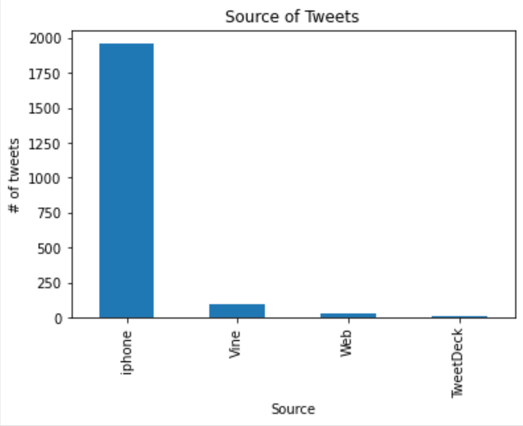

We can easly determine which source has most tweets, whitch is *iphone*